# Regression and Classification Revisited

Michael Mayer

2020-08-25

# 1 Basics

In this chapter, we will refresh the background on regression and classification, the two main branches of supervised learning. Before heading into regression and classification, we provide the very basics on data analysis and modeling.

## 1.1 Data organization

*Structured* data is organized as one or multiple tables. Each row of a table represents an *observation/instance*, each column $X$ a *variable* and each cell a *value*. A value of column $X$ can be viewed as a realization of the random variable $X$.

Examples of unstructured data are images, text, audio or video data. We will deal with structured data only.

Throughout this lecture, we will consider the following two data sets:

- `Titanic`: Passenger information, including the variable “survived: yes/no”. Each row represents a passenger.
- `diamonds`: Diamonds prices along with the four “C”-variables: Carat, Color, Cut, and Clarity. Each observation/row represents a diamond.

### 1.1.1 Example: diamonds

Let’s look at the first six observations of the diamonds data set.

```r
library(ggplot2) # Contains "diamonds"

head(diamonds)
```

| carat | cut | color | clarity | depth | table | price | x | y | z |
| --- | --- | --- | --- | --- | --- | --- | --- | --- | --- |
| 0.23 | Ideal | E | SI2 | 61.5 | 55 | 326 | 3.95 | 3.98 | 2.43 |
| 0.21 | Premium | E | SI1 | 59.8 | 61 | 326 | 3.89 | 3.84 | 2.31 |
| 0.23 | Good | E | VS1 | 56.9 | 65 | 327 | 4.05 | 4.07 | 2.31 |
| 0.29 | Premium | I | VS2 | 62.4 | 58 | 334 | 4.20 | 4.23 | 2.63 |
| 0.31 | Good | J | SI2 | 63.3 | 58 | 335 | 4.34 | 4.35 | 2.75 |
| 0.24 | Very Good | J | VVS2 | 62.8 | 57 | 336 | 3.94 | 3.96 | 2.48 |

The data set is neatly structured. It seems to be sorted by price.

## 1.2 Data types

We roughly distinguish the following data types.

- **numerical**: The values are discrete or continuous numbers where calculating averages makes sense. Examples: house prices, insurance claim frequencies, blood pressure.
- **categorical**: The values are categories, e.g. house types, claim types or colors. Depending on whether categories follow a natural order, we talk of *ordered* or *unordered* categoricals.
- **binary**: The variable just takes two values (male/female, yes/no, …) that can be represented by 0/1. A binary variable counts as both numeric and categorical.

Data types are important in determining suitable analysis methods.

### 1.2.1 Example: diamonds

In the `diamonds` data set, we will consider the numeric variables `price` and `carat` and the following *ordered* categoricals:

- `color` with ordered categories D < E < F < G < H < I < J,
- `cut` with ordered categories Fair < Good < Very Good < Premium < Ideal, and
- `clarity` with ordered categories I1 < SI2 < SI1 < VS2 < VS1 < VVS2 < VVS1 < IF.

There are no unordered categoricals or binary variables.

## 1.3 Descriptive Analysis

A modeling task always starts with an intensive descriptive analysis of the data sources. This typically involves numeric and/or graphical summary of each variable and the most relevant variable pairs, e.g.

- mean, standard deviation, quartiles, minimum and maximum for numeric variables (-> boxplots, plots of averages),
- mean for binary variables (-> barplots),
- absolute or relative counts for categorical variables (-> barplots),
- correlations and/or scatter plots for the most important pairs of numeric variables,
- frequency tables and/or mosaic plots for the most important pairs of categorical variables,
- stratified means and/or boxplots for the most important pairs of categorical *and* numerical variables.

The more time we invest in the descriptive analysis, the more we learn about the data, which is essential for successful modeling. Besides getting used to the data set, we might - identify data errors and gross outliers, - find join keys to combine multiple data sources, - detect variables with high number of missing values, - learn how the data is structured (what *is* a row? do we deal with time series? are rows grouped to clusters etc), - …

During or after the descriptive analysis, we usually do the *data preprocessing* for the modeling task.

### 1.3.1 Example: diamonds

Let’s summarize the diamonds data set.

```r
# Data size
nrow(diamonds)  # 53940
```

```
## [1] 53940
```

```r
# Univariate description
summary(diamonds[, c("price", "carat", "color", "cut", "clarity")])
```

```
##      price           carat        color            cut           clarity
##  Min.   :  326   Min.   :0.2000   D: 6775   Fair     : 1610   SI1    :13065
##  1st Qu.:  950   1st Qu.:0.4000   E: 9797   Good     : 4906   VS2    :12258
##  Median : 2401   Median :0.7000   F: 9542   Very Good:12082   SI2    : 9194
##  Mean   : 3933   Mean   :0.7979   G:11292   Premium  :13791   VS1    : 8171
##  3rd Qu.: 5324   3rd Qu.:1.0400   H: 8304   Ideal    :21551   VVS2   : 5066
##  Max.   :18823   Max.   :5.0100   I: 5422                     VVS1   : 3655
##                                   J: 2808                     (Other): 2531
```

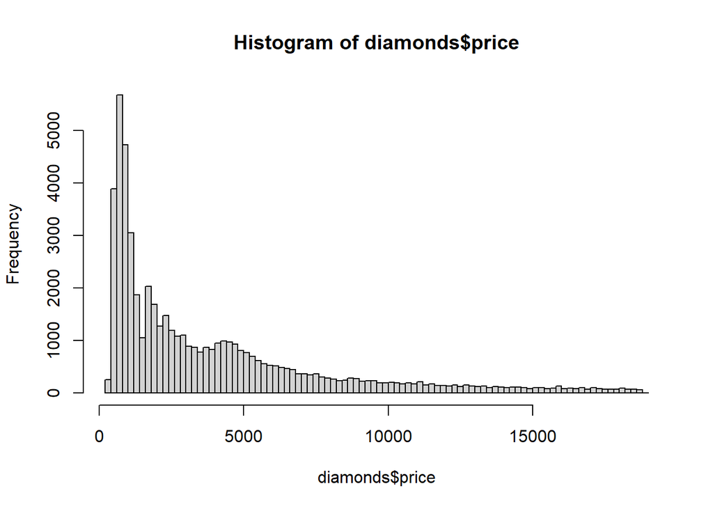

```r
hist(diamonds$price, breaks = "FD")
```

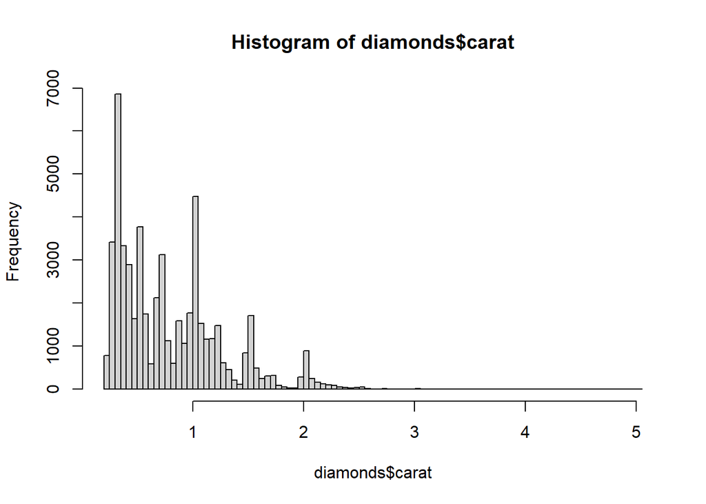

```r
hist(diamonds$carat, breaks = "FD")
```

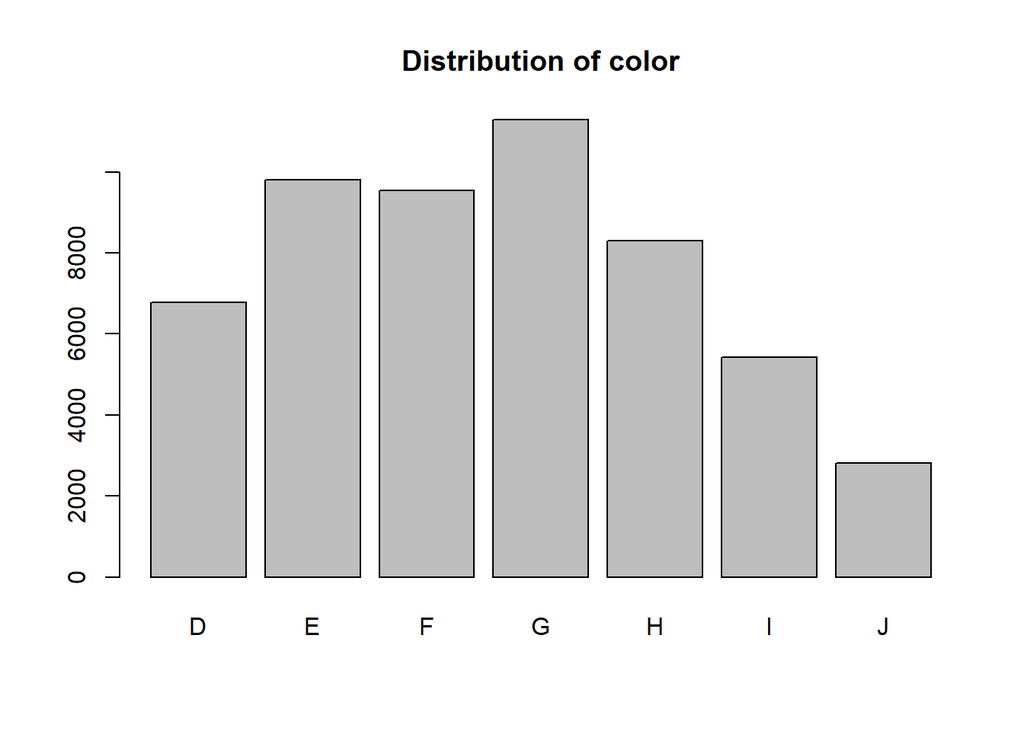

```r
barplot(table(diamonds$color), main = "Distribution of color")
```

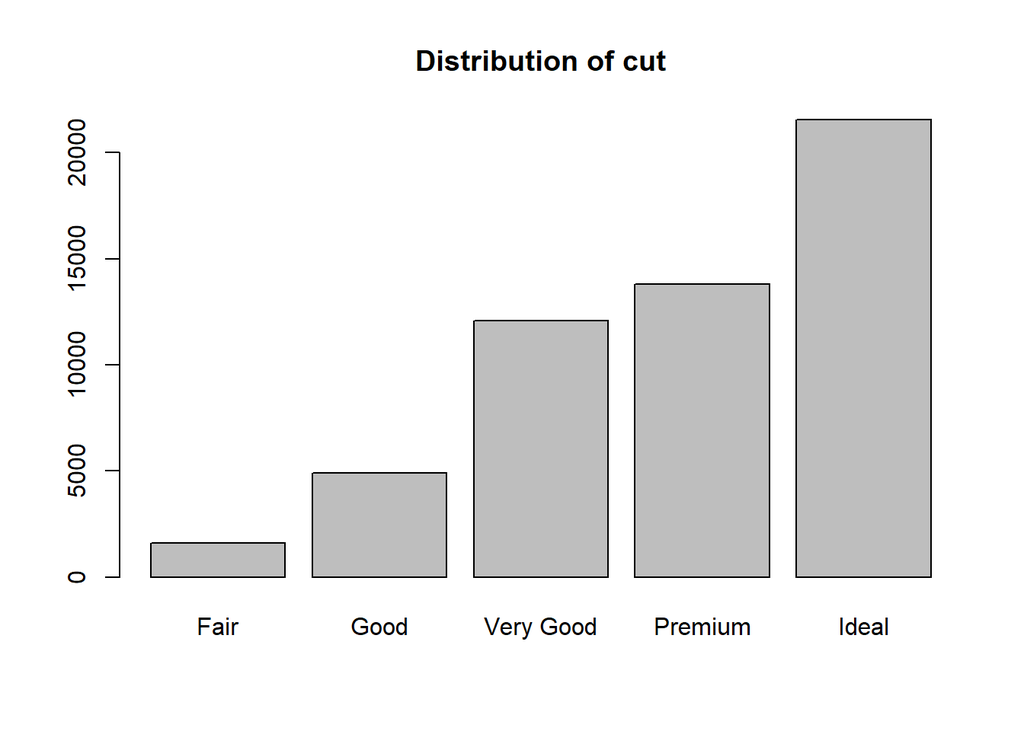

```r
barplot(table(diamonds$cut), main = "Distribution of cut")
```

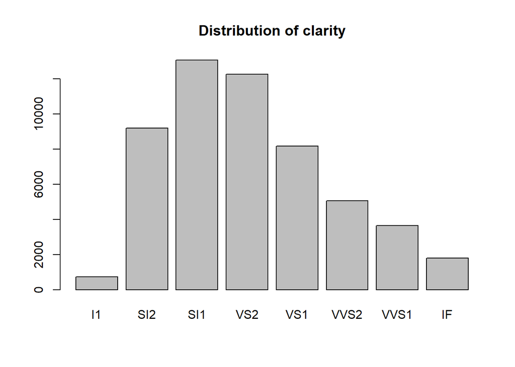

```r
barplot(table(diamonds$clarity), main = "Distribution of clarity")
```

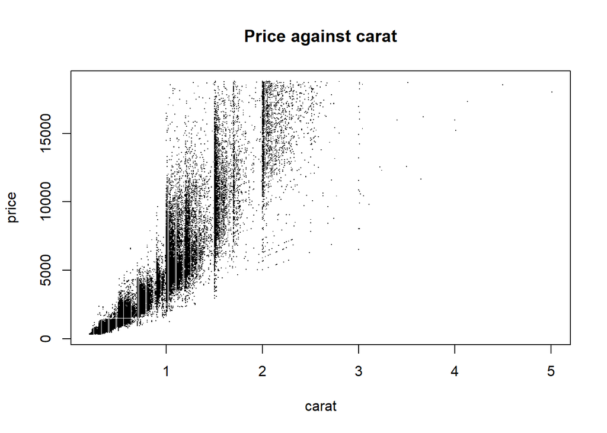

```r
# Selected bivariate descriptions
plot(price ~ carat, data = diamonds, pch = ".", main = "Price against carat")
```

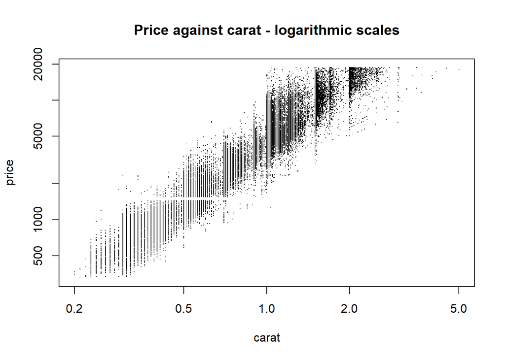

```r
plot(price ~ carat, data = diamonds, pch = ".", log = "xy",
     main = "Price against carat - logarithmic scales")
```

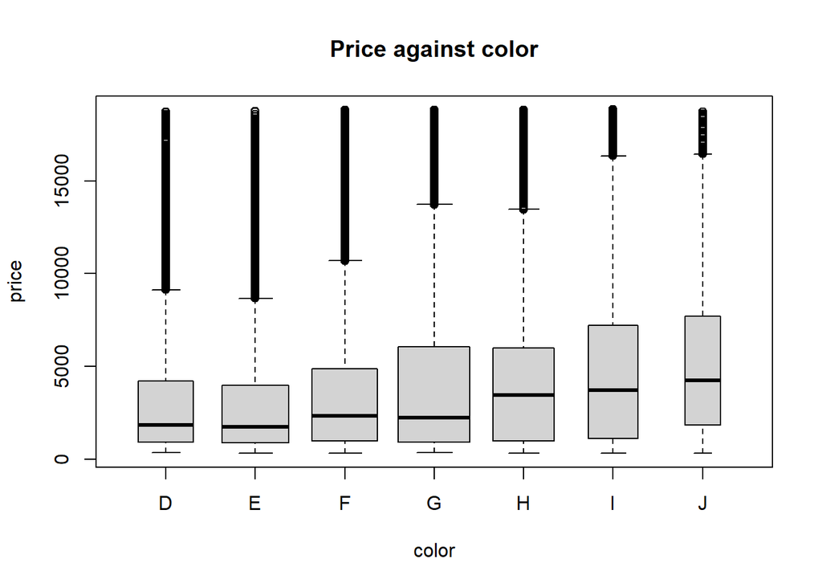

```r
boxplot(price ~ color, data = diamonds, varwidth = TRUE, main = "Price against color")
```

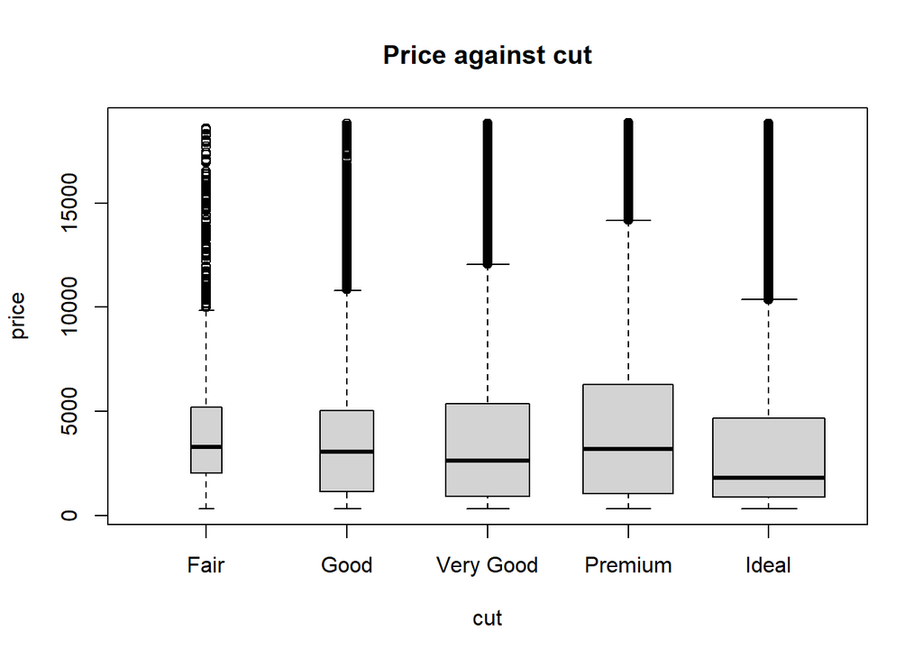

```r
boxplot(price ~ cut, data = diamonds, varwidth = TRUE, main = "Price against cut")
```

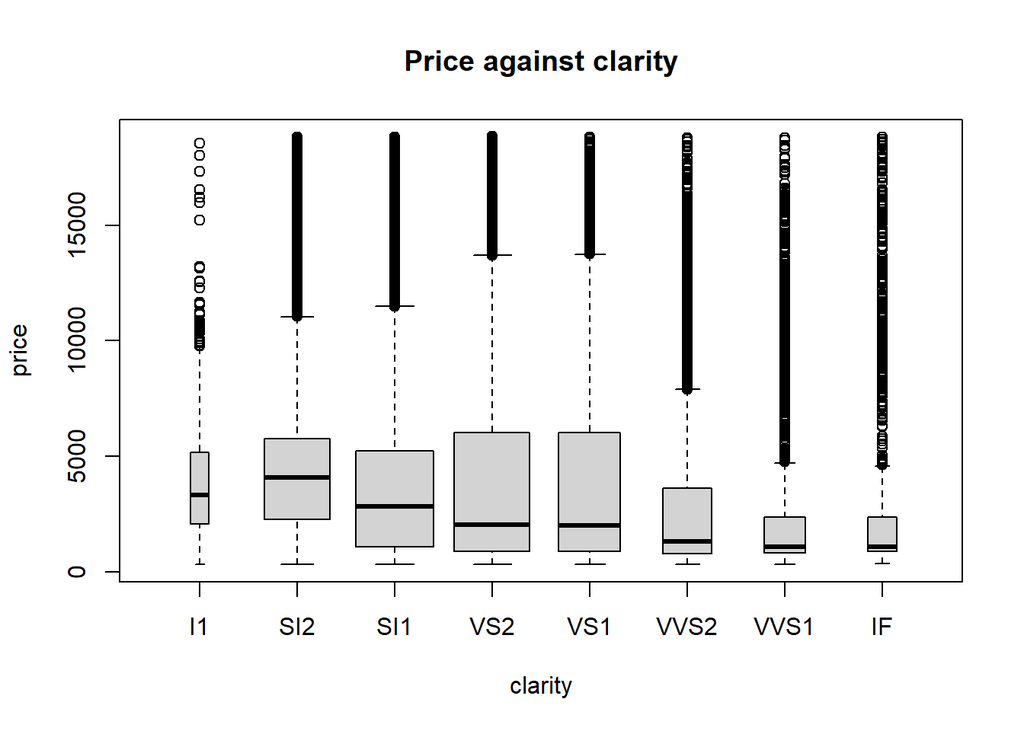

```r
boxplot(price ~ clarity, data = diamonds, varwidth = TRUE, main = "Price against clarity")
```

**Comments**

- Prices and carats are positive and right skewed with large outliers.
- Related: on (natural) logarithmic scale, the relationship between price and carat seems quite linear. We will use this insight later.
- The worst categories of `color`, `cut`, and `clarity` are rare.
- Prices tend to be lower for nice colors. This is unintuitive and might be explained by the fact that large diamonds have lower quality than small ones. More on this later.

## 1.4 The modeling task

Typically, we want to model a response variable $y$ by a function $f$ of covariables $X = (X_1, ..., X_m)$, i.e.
$$y \approx f(X).$$
Unlike in physics, the function $f$ is unknown and we want to estimate it by $\hat f$ from observed data.

Once found, $\hat f$ serves as our prediction function that can be applied to fresh data. Furthermore, we can investigate it to gain insights on the relationship between response and covariables like e.g. variable importance and covariable effects on the response.

**Remark:** Instead of *response variable*, we might say: output or target. Instead of *covariable*, we might say: input or feature.

# 2 Linear Regression

(Multiple) linear regression is the mother of all machine learning algorithms. It was first published by Legendre in 1805 and is still very frequently used thanks to its simplicity and interpretability. It further serves as a simple benchmark for more complex algorithms and is the starting point for extentions like generalized linear models.

Starting point is the additive linear regression equation
$$E(y) = f(X) = \beta_1 X_1 + \cdots \beta_m X_m$$
that relates the regressors $X_1, \dots, X_m$ to the expected response $E(y)$ by an affine linear formula in the parameter vector $\beta = (\beta_1, \dots, \beta_m)$. $X_1$ is an artificial variable with value 1 used for calibration and called *intercept*.

**Remarks**

- The model equation stresses the fact that our interest is not in modeling the full statistical distribution of the response but rather just one aspect, namely its expectation (= mean or average).
- By *regressor*, we mean a *numeric* variable derived from our covariables, see a bit later.
- A linear regression with just one covariable is called *simple* linear regression and has model equation $E(y) = \alpha + \beta X$.

The optimal $\hat f$ to estimate $f$ is found by minimizing the sum of squared model errors
$$\sum_{i=1}^n (y_i - \hat f(X^{(i)}))^2$$
across our $n$ observations, a very frequently used optimization situation in regression settings. $y_i$ and $X^{(i)}$ are the observed response and regressor vector of observation $1 \le i \le n$.

In *linear* regression, the optimal $\hat f$ resp. $\hat \beta$ is found analytically by the famous least-squares method. It is one of the only ML algorithms with an explicit solution. It involves a little bit of linear algebra. In practice, we let software do the hard work, so we add it just for the sake of completeness:
$$\hat \beta = (X'X)^{-1}X'y.$$
Here, $X$ is the so-called $(n \times m)$-design matrix or model matrix representing the $n$ observations of the $m$ regressors and $y$ is the response vector. The prime (’) means the matrix transpose.

## 2.1 Example: diamonds

In order to study the typical output of a linear regression, we now model diamond prices by their size.

```r
fit <- lm(price ~ carat, data = diamonds)
summary(fit)
```

```
##
## Call:
## lm(formula = price ~ carat, data = diamonds)
##
## Residuals:
##      Min       1Q   Median       3Q      Max
## -18585.3   -804.8    -18.9    537.4  12731.7
##
## Coefficients:
##             Estimate Std. Error t value Pr(>|t|)
## (Intercept) -2256.36      13.06  -172.8   <2e-16 ***
## carat        7756.43      14.07   551.4   <2e-16 ***
## ---
## Signif. codes:  0 '***' 0.001 '**' 0.01 '*' 0.05 '.' 0.1 ' ' 1
##
## Residual standard error: 1549 on 53938 degrees of freedom
## Multiple R-squared:  0.8493, Adjusted R-squared:  0.8493
## F-statistic: 3.041e+05 on 1 and 53938 DF,  p-value: < 2.2e-16
```

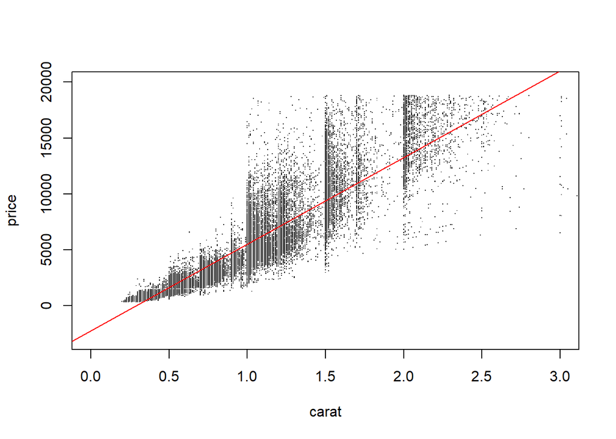

```r
# Visualize the regression line
plot(price ~ carat, data = diamonds, pch = ".",
     xlim = c(0, 3), ylim = c(-3000, 20000))
abline(fit, col = "red")
```

**Comments**

- In the equation $E(\text{price}) = \alpha + \beta \text{carat}$, the intercept $\alpha$ is estimated by $\hat \alpha = -2256$. Strictly speaking, this means that a 0 carat diamond costs -2256 USD, which is nonsensical but important for calibration.
- The slope $\beta$ is estimated by $\hat \beta = 7756$ USD. It means that a one carat increase goes along with an average increase in price of 7756 USD.
- The standard error estimates the standard deviation of the estimated coefficients. They are small compared to the coefficients, reflecting the fact that the sample is large and thus the sampling uncertainty small.
- The residual standard error (“deviation” would be a better word) is 1549. This means that residuals (= prediction errors) are typically around 1549 USD.
- The R-squared is the proportion of variability explained by the covariables. Here, about 85% of the price variability is due to the fact that not all diamonds are equally large. The remaining 15% is yet unexplained.

## 2.2 Common Problems

### 2.2.1 Missing values

As many algorithms, linear regression cannot deal with missing values. Rows with missing response variable can be safely dropped, while missings in covariables should usually be dealt with. The simplest (often too naive) approach is to fill missings with a typical value such as the mean or the most frequent value.

### 2.2.2 Outliers

Gross outliers in covariables can distort the result of the linear regression. Don’t delete them, but try to reduce their effect by taking logarithms or look for a more robust alternative to least-squares regression.

### 2.2.3 Overfitting

If too many parameters are fitted in relation to the number of observations, the resulting model might look good but would not generalize well to new data. This is called overfitting. A small amound of it is unproblematic. But don’t dare to fit a model with $m=100$ parameters on a data set with just $n=200$ rows. A $n/m$ ratio of 50 is usually safe.

## 2.3 Representation of covariables

Depending on the specific situation, covariables might need to be transformed into one or multiple numeric *regressors*:

- Categoricals are usually *dummy* encoded. This means that each category is represented by its own binary variable (“am I in this category yes/no?”). This is often done implicitly by the software. Rare categories can be lumped together in order to not estimate too many parameters.
- Besides dummy coding, ordered categoricals are sometimes *integer encoded* for simplicity i.e. each category is represented by an integer number instead a of a binary variable. This assumes (approximate) equally spaced categories.
- Positive numeric variables can be log-transformed to deal with large outliers and/or to bring it to a relative scale.
- Important numeric covariables might be represented by more than just one parameter (= slope) to allow for a more flexible association to the response. Adding a squared term e.g. allows for curvature. More flexible are regression splines. They can approximate arbitrary smooth relationships at the price of interpretability.
- Strongly related covariables can be decorrelated to improve interpretation of results. A typical example are house price models. There, number of rooms and living area are strongly related and therefore, it might help to represent living area by the derived variable “living area per room”.
- As a consequence of the additive model structure, each covariable acts independently on the response. This is not always the case. E.g. being flawless means more to a large diamond than to a small diamond. In such cases, adding interaction terms might be worth the effort. Since interactions complicate the interpretation of the results, they should be used with care and only for the most important covariables.

## 2.4 Example: diamonds imporved

Now, we try to improve our simple linear regression in two ways.

1. We add color, cut and clarity (implicitly as dummy variables).
2. We model logarithmic price and carat.

```r
dia <- transform(diamonds,
                 color_ = factor(color, ordered = FALSE),
                 cut_ = factor(cut, ordered = FALSE),
                 clarity_ = factor(clarity, ordered = FALSE))
fit <- lm(log(price) ~ log(carat) + color_ + cut_ + clarity_, data = dia)
summary(fit)
```

```
##
## Call:
## lm(formula = log(price) ~ log(carat) + color_ + cut_ + clarity_,
##     data = dia)
##
## Residuals:
##      Min       1Q   Median       3Q      Max
## -1.01107 -0.08636 -0.00023  0.08341  1.94778
##
## Coefficients:
##                Estimate Std. Error t value Pr(>|t|)
## (Intercept)    7.856856   0.005758 1364.43   <2e-16 ***
## log(carat)     1.883718   0.001129 1668.75   <2e-16 ***
## color_E       -0.054277   0.002118  -25.62   <2e-16 ***
## color_F       -0.094596   0.002142  -44.16   <2e-16 ***
## color_G       -0.160378   0.002097  -76.49   <2e-16 ***
## color_H       -0.251071   0.002225 -112.85   <2e-16 ***
## color_I       -0.372574   0.002492 -149.50   <2e-16 ***
## color_J       -0.510983   0.003074 -166.24   <2e-16 ***
## cut_Good       0.080048   0.003890   20.57   <2e-16 ***
## cut_Very Good  0.117215   0.003619   32.39   <2e-16 ***
## cut_Premium    0.139345   0.003579   38.94   <2e-16 ***
## cut_Ideal      0.161218   0.003548   45.44   <2e-16 ***
## clarity_SI2    0.427879   0.005178   82.64   <2e-16 ***
## clarity_SI1    0.592954   0.005149  115.17   <2e-16 ***
## clarity_VS2    0.742164   0.005178  143.34   <2e-16 ***
## clarity_VS1    0.812277   0.005257  154.52   <2e-16 ***
## clarity_VVS2   0.947271   0.005418  174.83   <2e-16 ***
## clarity_VVS1   1.018743   0.005575  182.73   <2e-16 ***
## clarity_IF     1.113732   0.006030  184.69   <2e-16 ***
## ---
## Signif. codes:  0 '***' 0.001 '**' 0.01 '*' 0.05 '.' 0.1 ' ' 1
##
## Residual standard error: 0.1338 on 53921 degrees of freedom
## Multiple R-squared:  0.9826, Adjusted R-squared:  0.9826
## F-statistic: 1.693e+05 on 18 and 53921 DF,  p-value: < 2.2e-16
```

# 3 Binary classification